# EDA

```python
import numpy as np
import pandas as pd
import lux
```

```python
df =pd.read_csv('data.csv')

df
```

```python
print("The dataset contains 1111742 entries.")
print("There are total" ,df['Id'].nunique()," unique players available in the dataset")
print("Total groups in the dataset are ",df['groupId'].nunique()," which might be playing in multiple matches")
print("Total matches occured are ",df['matchId'].nunique())
print("Maximum players in group can be 4 while max group(teams) which can participate in a match are 100")
```

```
The dataset contains 1111742 entries.
There are total 1111742  unique players available in the dataset
Total groups in the dataset are  870622  which might be playing in multiple matches
Total matches occured are  47951
Maximum players in group can be 4 while max group(teams) which can participate in a match are 100
```

```python
df.info()
```

```
<class 'lux.core.frame.LuxDataFrame'>
RangeIndex: 1111742 entries, 0 to 1111741
Data columns (total 30 columns):
 #   Column           Non-Null Count    Dtype
---  ------           --------------    -----
 0   Unnamed: 0       1111742 non-null  int64
 1   Id               1111742 non-null  object
 2   groupId          1111742 non-null  object
 3   matchId          1111742 non-null  object
 4   assists          1111742 non-null  int64
 5   boosts           1111742 non-null  int64
 6   damageDealt      1111742 non-null  float64
 7   DBNOs            1111742 non-null  int64
 8   headshotKills    1111742 non-null  int64
 9   heals            1111742 non-null  int64
```

[output cut: 22 more lines]

```python
df.dropna(inplace=True)
df.drop_duplicates(inplace=True)
df
```

|  | Unnamed: 0 | Id | groupId | matchId | assists | boosts | damageDealt | DBNOs | headshotKills | heals | ... | revives | rideDistance | roadKills | swimDistance | teamKills | vehicleDestroys | walkDistance | weaponsAcquired | winPoints | winPlacePerc |
| --- | --- | --- | --- | --- | --- | --- | --- | --- | --- | --- | --- | --- | --- | --- | --- | --- | --- | --- | --- | --- | --- |
| 0 | 2093518 | a3e3cea9f2e314 | c9f6eaa81245b5 | a3d8693390584c | 0 | 0 | 25.93 | 0 | 0 | 0 | ... | 0 | 0.0 | 0 | 0.000 | 0 | 0 | 151.30 | 1 | 1525 | 0.0667 |
| 1 | 3701672 | 43e4be7ad72cc7 | 521836de101ee8 | b65de9055327e0 | 0 | 0 | 36.71 | 0 | 0 | 0 | ... | 0 | 0.0 | 0 | 0.000 | 0 | 0 | 1918.00 | 7 | 1516 | 0.5862 |
| 2 | 2059784 | 9a68690e31fdff | 4a72ffa2cebd90 | d6aad3f9830e60 | 0 | 1 | 47.73 | 0 | 0 | 0 | ... | 0 | 4088.0 | 0 | 0.000 | 0 | 0 | 820.00 | 7 | 0 | 0.8105 |
| 3 | 1302036 | b147e1bd448fc4 | 9a8991656b3fea | d931c0932d8aca | 0 | 0 | 0.00 | 0 | 0 | 0 | ... | 1 | 0.0 | 0 | 0.000 | 0 | 0 | 38.81 | 0 | 1515 | 0.5556 |
| 4 | 297180 | d818b4edd59612 | eece87c8b846b3 | ec2b5ed94baae3 | 0 | 2 | 100.00 | 0 | 0 | 3 | ... | 0 | 918.4 | 0 | 0.000 | 0 | 0 | 1721.00 | 5 | 0 | 0.6429 |
| ... | ... | ... | ... | ... | ... | ... | ... | ... | ... | ... | ... | ... | ... | ... | ... | ... | ... | ... | ... | ... | ... |
| 1111737 | 4209703 | 43739241d6a8e8 | afb7c87045825e | ad5719d2422207 | 0 | 0 | 70.31 | 0 | 0 | 0 | ... | 0 | 0.0 | 0 | 0.000 | 0 | 0 | 799.80 | 2 | 0 | 0.3929 |
| 1111738 | 4311549 | d57c8a22a9e38b | 85e0624ddd2cb0 | c3f50eef6dbb01 | 0 | 3 | 334.10 | 0 | 0 | 1 | ... | 0 | 1549.0 | 0 | 0.000 | 0 | 0 | 2777.00 | 7 | 0 | 0.8542 |
| 1111739 | 3521011 | c7ad131758ba55 | b3759687b385b3 | 990a8d68ec2bc4 | 0 | 0 | 119.30 | 1 | 0 | 0 | ... | 0 | 0.0 | 0 | 0.000 | 0 | 0 | 60.45 | 1 | 0 | 0.7174 |
| 1111740 | 2138826 | 8237d06ea2c508 | 13a05023ab7735 | f93b1f0defaee5 | 1 | 4 | 53.51 | 1 | 0 | 7 | ... | 1 | 3610.0 | 0 | 0.000 | 1 | 0 | 2209.00 | 4 | 0 | 0.9000 |
| 1111741 | 609836 | 9beb0064c56445 | 5cfa1834dc5b11 | 0406ce4ab7a1bd | 5 | 3 | 607.40 | 3 | 0 | 3 | ... | 0 | 713.9 | 0 | 8.912 | 0 | 0 | 3713.00 | 5 | 1611 | 1.0000 |

1111741 rows × 30 columns

```python
mgb = df.groupby(['matchId'])
```

```python
mgb.first()
```

[output not shown]

```python
ggb = df.groupby(["matchId",'groupId'])
```

```python
ggb.first()
```

| matchId | groupId | Unnamed: 0 | Id | assists | boosts | damageDealt | DBNOs | headshotKills | heals | killPlace | killPoints | ... | revives | rideDistance | roadKills | swimDistance | teamKills | vehicleDestroys | walkDistance | weaponsAcquired | winPoints | winPlacePerc |
| --- | --- | --- | --- | --- | --- | --- | --- | --- | --- | --- | --- | --- | --- | --- | --- | --- | --- | --- | --- | --- | --- | --- |
| 0000a43bce5eec | 18b16ec699d8b6 | 2843474 | 6703bc191cff0a | 0 | 1 | 19.35 | 0 | 0 | 0 | 61 | 1065 | ... | 0 | 0.0 | 0 | 0.0 | 0 | 0 | 189.400 | 1 | 1484 | 0.3333 |
|  | 236ab9e9c081b9 | 1998699 | e431d8a8f6c99b | 0 | 0 | 21.29 | 0 | 0 | 0 | 92 | 1470 | ... | 0 | 0.0 | 0 | 0.0 | 0 | 0 | 5.201 | 1 | 1503 | 0.0370 |
|  | 4bf06994bd4c9a | 918045 | 29ffb3ea02be3e | 0 | 0 | 0.00 | 0 | 0 | 0 | 60 | 1189 | ... | 0 | 0.0 | 0 | 0.0 | 0 | 0 | 347.700 | 2 | 1433 | 0.3704 |
|  | 6620b219ed2ee2 | 2251382 | b66a690a2c32f9 | 1 | 2 | 155.50 | 0 | 0 | 2 | 37 | 1319 | ... | 1 | 385.8 | 0 | 0.0 | 0 | 0 | 3397.000 | 3 | 1454 | 0.7778 |
|  | 6c44ef4381fe8d | 1330902 | 644c42b440c778 | 0 | 4 | 629.90 | 3 | 1 | 1 | 4 | 1526 | ... | 0 | 0.0 | 0 | 0.0 | 0 | 0 | 2458.000 | 3 | 1515 | 0.7037 |
| ... | ... | ... | ... | ... | ... | ... | ... | ... | ... | ... | ... | ... | ... | ... | ... | ... | ... | ... | ... | ... | ... | ... |
| fffe92232706aa | abc744463b2dd4 | 4173704 | c011eb1544516e | 0 | 1 | 62.81 | 0 | 0 | 3 | 56 | 0 | ... | 0 | 856.3 | 0 | 0.0 | 0 | 0 | 743.200 | 7 | 0 | 0.4286 |
|  | b671eab579d429 | 3639771 | 4d3f134bed290d | 0 | 0 | 16.95 | 0 | 0 | 0 | 29 | 0 | ... | 0 | 1732.0 | 0 | 0.0 | 0 | 0 | 2988.000 | 3 | 0 | 0.6429 |
|  | bd5b4ecf8067ab | 3326745 | 97d05b2006ca5b | 0 | 4 | 254.20 | 0 | 0 | 8 | 22 | 0 | ... | 2 | 4297.0 | 0 | 0.0 | 0 | 0 | 2404.000 | 6 | 0 | 0.9286 |
|  | d57f3a3ed40913 | 1850370 | 05b14fa2df4baa | 0 | 1 | 0.00 | 0 | 0 | 0 | 69 | 0 | ... | 0 | 0.0 | 0 | 0.0 | 0 | 0 | 590.000 | 4 | 0 | 0.2500 |
|  | d8fa9cfd6f9560 | 656414 | 26527c6a1615d7 | 0 | 2 | 0.00 | 0 | 0 | 0 | 55 | 0 | ... | 0 | 510.2 | 0 | 0.0 | 0 | 0 | 1589.000 | 5 | 0 | 0.4643 |

870621 rows × 28 columns

Using df.describe() to return all description of data , which includes mean, median, percentiles ranges, minimum value, maximum value and null entries

```python
df.describe()
```

[output not shown]

[output not shown]

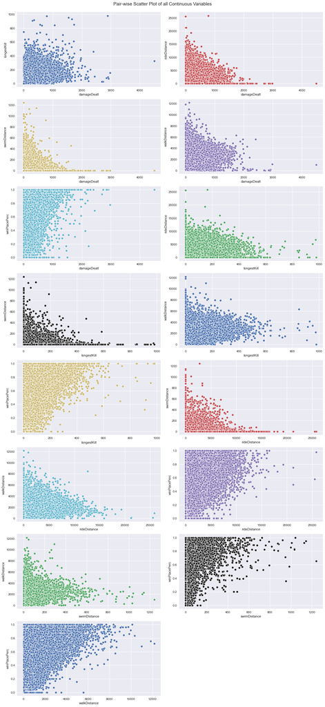

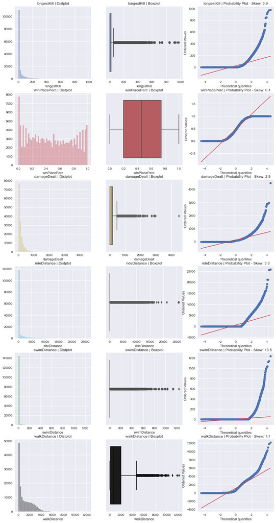

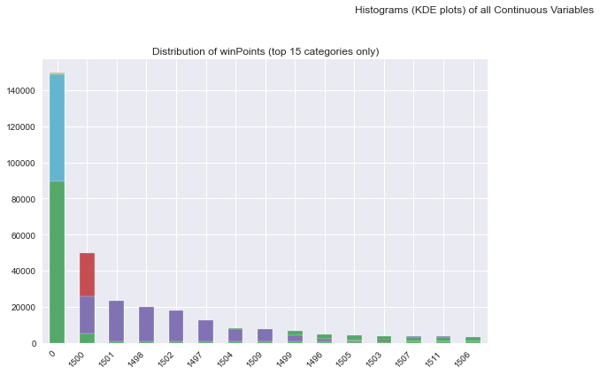

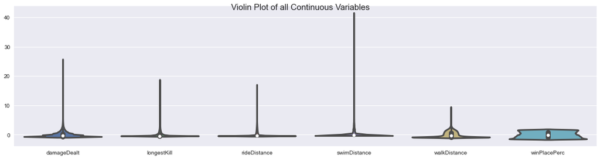

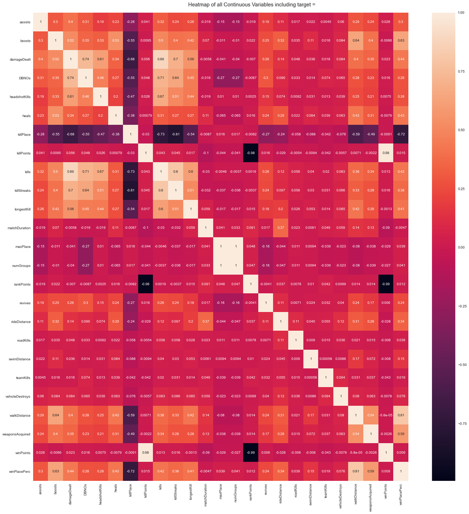

[figure not shown]

```
Time to run AutoViz (in seconds) = 71.023

 ###################### VISUALIZATION Completed ########################
```

```python
from autoviz.AutoViz_Class import AutoViz_Class
AV = AutoViz_Class()
dt = AV.AutoViz('data.csv')
```

```python
df.head()
```

|  | Unnamed: 0 | Id | groupId | matchId | assists | boosts | damageDealt | DBNOs | headshotKills | heals | ... | revives | rideDistance | roadKills | swimDistance | teamKills | vehicleDestroys | walkDistance | weaponsAcquired | winPoints | winPlacePerc |
| --- | --- | --- | --- | --- | --- | --- | --- | --- | --- | --- | --- | --- | --- | --- | --- | --- | --- | --- | --- | --- | --- |
| 0 | 2093518 | a3e3cea9f2e314 | c9f6eaa81245b5 | a3d8693390584c | 0 | 0 | 25.93 | 0 | 0 | 0 | ... | 0 | 0.0 | 0 | 0.0 | 0 | 0 | 151.30 | 1 | 1525 | 0.0667 |
| 1 | 3701672 | 43e4be7ad72cc7 | 521836de101ee8 | b65de9055327e0 | 0 | 0 | 36.71 | 0 | 0 | 0 | ... | 0 | 0.0 | 0 | 0.0 | 0 | 0 | 1918.00 | 7 | 1516 | 0.5862 |
| 2 | 2059784 | 9a68690e31fdff | 4a72ffa2cebd90 | d6aad3f9830e60 | 0 | 1 | 47.73 | 0 | 0 | 0 | ... | 0 | 4088.0 | 0 | 0.0 | 0 | 0 | 820.00 | 7 | 0 | 0.8105 |
| 3 | 1302036 | b147e1bd448fc4 | 9a8991656b3fea | d931c0932d8aca | 0 | 0 | 0.00 | 0 | 0 | 0 | ... | 1 | 0.0 | 0 | 0.0 | 0 | 0 | 38.81 | 0 | 1515 | 0.5556 |
| 4 | 297180 | d818b4edd59612 | eece87c8b846b3 | ec2b5ed94baae3 | 0 | 2 | 100.00 | 0 | 0 | 3 | ... | 0 | 918.4 | 0 | 0.0 | 0 | 0 | 1721.00 | 5 | 0 | 0.6429 |

5 rows × 30 columns

```python
df.tail()
```

|  | Unnamed: 0 | Id | groupId | matchId | assists | boosts | damageDealt | DBNOs | headshotKills | heals | ... | revives | rideDistance | roadKills | swimDistance | teamKills | vehicleDestroys | walkDistance | weaponsAcquired | winPoints | winPlacePerc |
| --- | --- | --- | --- | --- | --- | --- | --- | --- | --- | --- | --- | --- | --- | --- | --- | --- | --- | --- | --- | --- | --- |
| 1111737 | 4209703 | 43739241d6a8e8 | afb7c87045825e | ad5719d2422207 | 0 | 0 | 70.31 | 0 | 0 | 0 | ... | 0 | 0.0 | 0 | 0.000 | 0 | 0 | 799.80 | 2 | 0 | 0.3929 |
| 1111738 | 4311549 | d57c8a22a9e38b | 85e0624ddd2cb0 | c3f50eef6dbb01 | 0 | 3 | 334.10 | 0 | 0 | 1 | ... | 0 | 1549.0 | 0 | 0.000 | 0 | 0 | 2777.00 | 7 | 0 | 0.8542 |
| 1111739 | 3521011 | c7ad131758ba55 | b3759687b385b3 | 990a8d68ec2bc4 | 0 | 0 | 119.30 | 1 | 0 | 0 | ... | 0 | 0.0 | 0 | 0.000 | 0 | 0 | 60.45 | 1 | 0 | 0.7174 |
| 1111740 | 2138826 | 8237d06ea2c508 | 13a05023ab7735 | f93b1f0defaee5 | 1 | 4 | 53.51 | 1 | 0 | 7 | ... | 1 | 3610.0 | 0 | 0.000 | 1 | 0 | 2209.00 | 4 | 0 | 0.9000 |
| 1111741 | 609836 | 9beb0064c56445 | 5cfa1834dc5b11 | 0406ce4ab7a1bd | 5 | 3 | 607.40 | 3 | 0 | 3 | ... | 0 | 713.9 | 0 | 8.912 | 0 | 0 | 3713.00 | 5 | 1611 | 1.0000 |

5 rows × 30 columns

Printing shape, decription and nature of data, null entries for each colums

```python
print(df.shape)
print(df.isnull().sum())
print(df.dtypes)
```

```
(1111741, 30)
Unnamed: 0         0
Id                 0
groupId            0
matchId            0
assists            0
boosts             0
damageDealt        0
DBNOs              0
headshotKills      0
heals              0
killPlace          0
killPoints         0
kills              0
killStreaks        0
longestKill        0
matchDuration      0
matchType          0
maxPlace           0
numGroups          0
rankPoints         0
revives            0
rideDistance       0
roadKills          0
swimDistance       0
teamKills          0
vehicleDestroys    0
walkDistance       0
weaponsAcquired    0
winPoints          0
winPlacePerc       0
dtype: int64

Unnamed: 0           int64
Id                  object
groupId             object
matchId             object
assists              int64
boosts               int64
damageDealt        float64
```

[output cut: 9 more lines]

```
matchType           object
maxPlace             int64
numGroups            int64
rankPoints           int64
revives              int64
rideDistance       float64
roadKills            int64
swimDistance       float64
teamKills            int64
vehicleDestroys      int64
walkDistance       float64
weaponsAcquired      int64
winPoints            int64
winPlacePerc       float64
dtype: object
```

```python
m_types = df.loc[:,"matchType"].value_counts().to_frame().reset_index()
m_types.columns = ["Type","Count"]
m_types['Percentage'] =m_types.Count / m_types.Count.sum() *100
m_types
```

[output not shown]

**Univariate Analysis** -> PDF, Histograms, Boxplots, Countplots, etc..

- Understand the probability and frequency distribution of each numerical column
- Understand the frequency distribution of each categorical Variable/Column

[figure not shown]

```python
import matplotlib.pyplot as plt
import seaborn as sns
plt.figure(figsize=(10,7))
sns.countplot(df['kills'].astype('str').sort_values())
plt.title("Kill Count",fontsize=15)
plt.show()
```

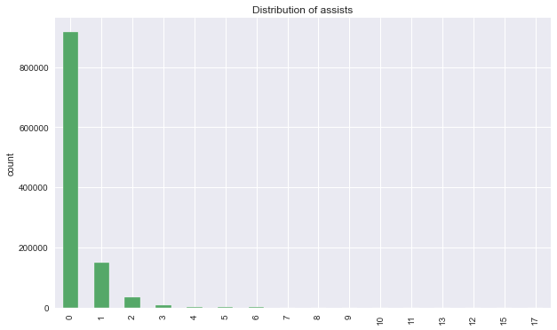

```python
plt.figure(figsize=[10,6])
df['assists'].value_counts().plot(kind='bar',color="g")
plt.title("Distribution of assists")
plt.ylabel("count")
plt.show()
print(df['assists'].value_counts())
```

[figure not shown]

```python
df['boosts'].value_counts().plot(kind='bar')
plt.title("Distribution of boosts")
plt.ylabel("count")
plt.show()
print(df['boosts'].value_counts())
```

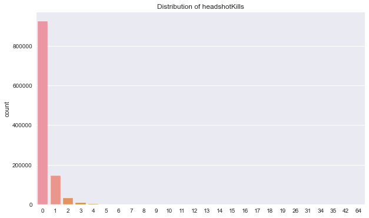

```python
plt.figure(figsize=[10,6])
sns.countplot(df['headshotKills'].sort_values())
plt.title("Distribution of headshotKills")
plt.ylabel("count")
plt.show()
```

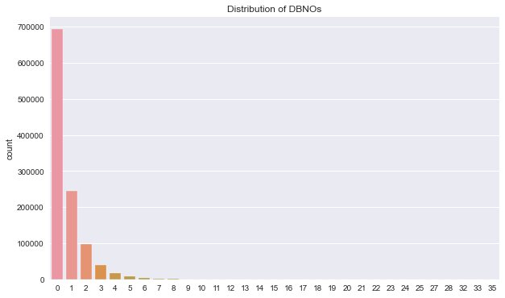

```python
plt.figure(figsize=[10,6])
sns.countplot(df['DBNOs'].sort_values())
plt.title("Distribution of DBNOs")
plt.ylabel("count")
plt.show()
```

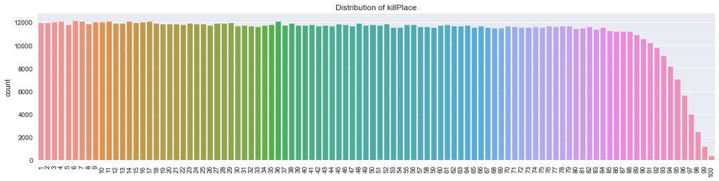

```python
plt.figure(figsize=[18,4])
sns.countplot(df['killPlace'].sort_values())
plt.title("Distribution of killPlace")
plt.ylabel("count")
plt.xticks(rotation=90)
plt.show()
```

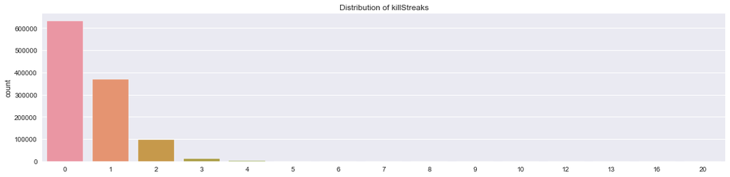

```python
plt.figure(figsize=[18,4])
sns.countplot(df['killStreaks'].sort_values())
plt.title("Distribution of killStreaks")
plt.ylabel("count")
plt.show()
```

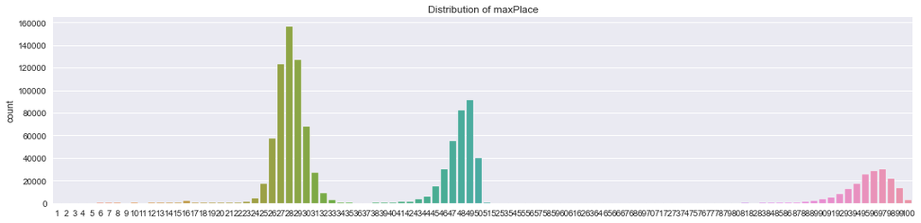

```python
plt.figure(figsize=[18,4])
sns.countplot(df['maxPlace'].sort_values())
plt.title("Distribution of maxPlace")
plt.ylabel("count")
plt.show()
```

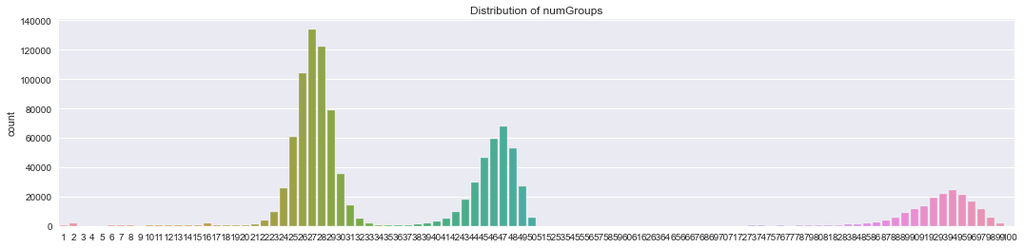

```python
plt.figure(figsize=[18,4])
sns.countplot(df['numGroups'].sort_values())
plt.title("Distribution of numGroups")
plt.ylabel("count")
plt.show()
```

As we can see from above two fraphs the number of groups in a match and max places is nearly similar because the total places will always depend upon the teams in a match. to confirm this relationship we will plot realtionship graph.

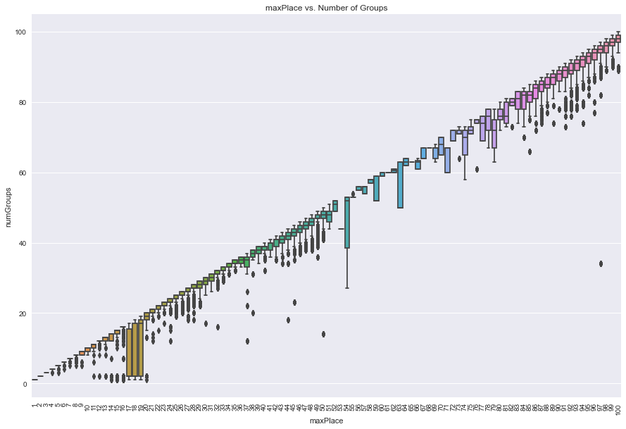

```python
plt.figure(figsize=(15,10))
ax1 = sns.boxplot(x="maxPlace",y="numGroups", data = df)
plt.title("maxPlace vs. Number of Groups")
plt.xticks(rotation=90)
plt.show()
```

Also from the previous observations and game understandings kills and damage dealt will be proportional to each other, Hence we will perform similar analysis to confirm this.

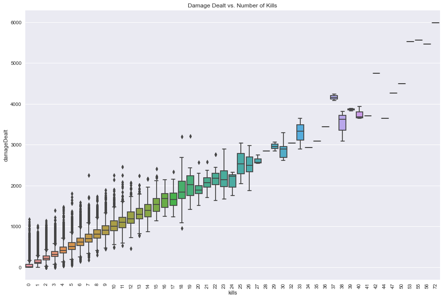

```python
plt.figure(figsize=(15,10))
ax1 = sns.boxplot(x="kills",y="damageDealt", data = df)
plt.title("Damage Dealt vs. Number of Kills")
plt.xticks(rotation=90)
plt.show()
```

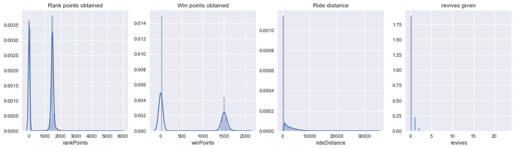

```python
plt.figure(figsize=(18,10))
plt.subplot(244)
sns.distplot(df['revives'])
plt.title("revives given")
plt.subplot(241)
sns.distplot(df['rankPoints'])
plt.title("Rank points obtained")
plt.subplot(242)
sns.distplot(df['winPoints'])
plt.title("Win points obtained")
plt.subplot(243)
sns.distplot(df['rideDistance'])
plt.title("Ride distance")
plt.show()
```

**Bivariate Analysis**

- Discover the relationships between numerical columns using Scatter plots, hexbin plots, pair plots, etc..
- Identify the patterns between categorical and numerical columns using swarmplot, boxplot, barplot, etc..

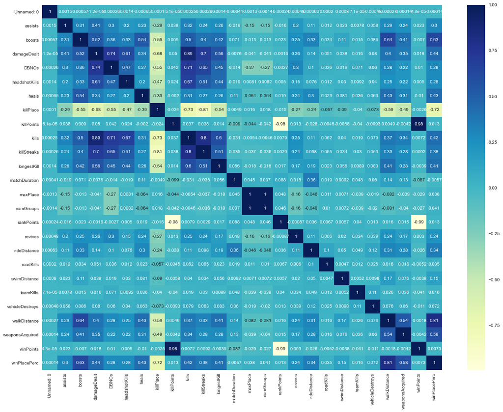

```python
plt.figure(figsize=(20,15))
sns.heatmap(df.corr(),annot=True,cmap='YlGnBu')
plt.show()
```

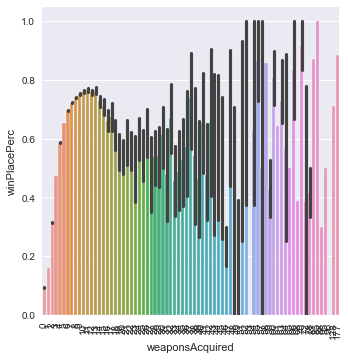

```python
plt.figure(figsize=(20,10))
sns.factorplot(x='weaponsAcquired', y='winPlacePerc',kind='bar',data=df)
plt.xticks(rotation=90)
plt.show()
```

As we can see from above figure even if number of weapons acquired increases does not always result in win placement percentage increase also, but for good winning chances (>0.7) number of weapons is mostly in range 5-14 weapons

```python
walk0 = (df["walkDistance"] == 0)
ride0 = (df["rideDistance"] == 0)
swim0 = (df["swimDistance"] == 0)
print("{} of players didn't walk at all, {} players didn't drive and {} didn't swim." .format(walk0.sum(),ride0.sum(),swim0.sum()))
```

```
24936 of players didn't walk at all, 827573 players didn't drive and 1039125 didn't swim.
```

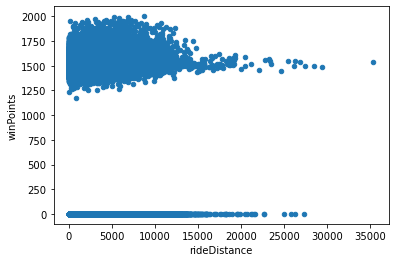

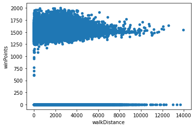

```python
import matplotlib.pyplot as plt
import seaborn as sns
t = df[df['rideDistance']>0]
t.plot(x='rideDistance',y='winPoints',kind='scatter')

p = df[df['walkDistance']>0]
p.plot(x='walkDistance',y='winPoints',kind='scatter')
plt.show()
```